# Module 4 Lab: Human Activity Recognition w/ KNN & Cross-Validation

Author

Ben Falandays

**Learning Objectives**

Our learning objectives for this module are:

- Understand the bias-variance tradeoff (accuracy vs overfitting)
- Understand the k-nearest neighbors algorithm for classification and implement it with tidymodels
- Use cross-validation to tune the value of k

Our cellphones and smartwatches record a lot of different kinds of data. There’s our search history and web traffic, of course, but also GPS, audio data, and a variety of sensors, including a gyroscope, accelerometer, and gravity sensor. In this module, we’ll see how that sensor data can be used to predict what a user is doing during some interval of time–whether they’re sitting down, riding a bike, driving a car, etc. This type of analysis could be useful for a tech company to figure out your interests and serve up targeted ads, or to deliver content/functionality at just the right moment (e.g. maybe you want your maps interface to change automatically depending upon whether you are biking, driving, or walking).

The dataset for this module contains summarized data (i.e. means, maxs, mins, etc) from the accelerometer, gyroscope, and gravity sensor of a smartwatch while participants performed various actions. We will use the k-nearest neighbors (knn) algorithm to classify the activity being performed. Then, we will use k-fold cross-validation to tune the parameters of our knn model in order to get the highest classification accuracy, while avoiding overfitting.

## Library and data loading

```r
library(tidyverse)
library(tidymodels)
library(broom)
library(themis)

df = rbind(read_csv('./data/OriginalProcessedData.csv'), read_csv('./data/NewProcessedData.csv'))

colnames(df) <- gsub("~","", colnames(df))

df$Activity = factor(df$Activity)
```

# Data visualization and exploration

**Exercise 1**

First, make a bar plot showing the number of observations of each type of `Activity`.

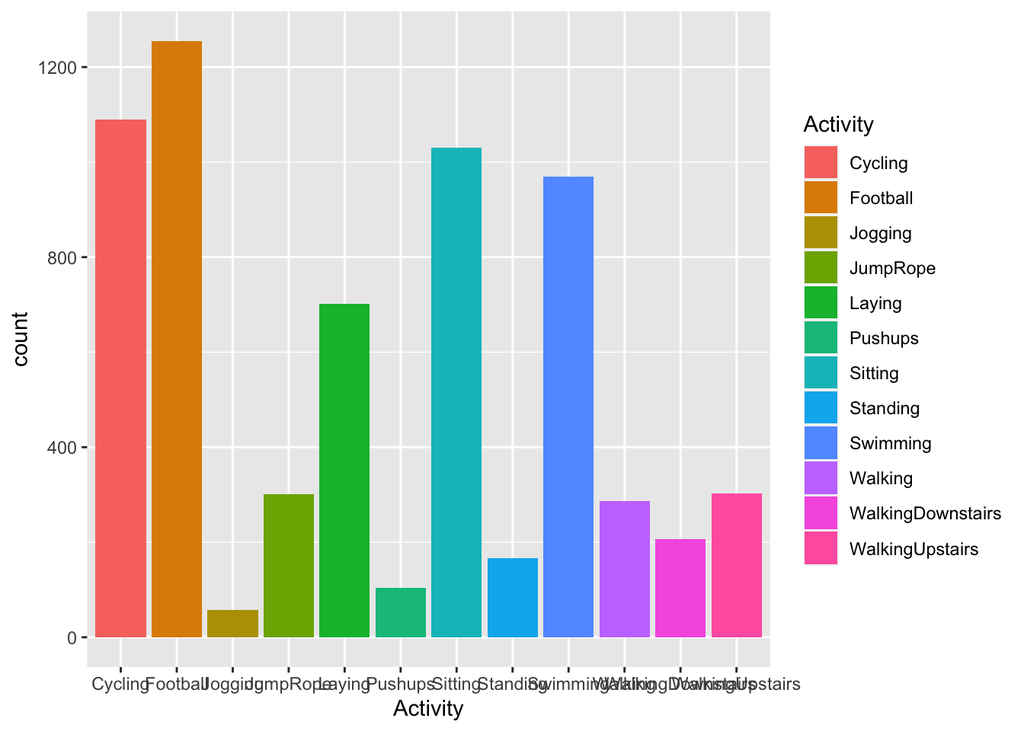

```r
ggplot(df, aes(x = Activity, fill = Activity))+geom_bar()
```

One thing to notice is that we have substantial “class imbalance,” meaning there are many observations of some activities–such as cycling and football–and far fewer observations of other activities, such as jogging and pushups. Class imbalance can cause problems for our model, because the training data is driven much more strongly by only a subset of activities.

To deal with this problem, we can use resampling techniques. We can either “upsample,” resample rows from classes with fewer observations, or “downsample,” excluding rows from classes with more observations.

In this case, we will try upsampling using the `step_upsample()` function. We set `over_ratio` to .5, meaning we will oversample the classes with fewer observations until they have 50% as many observations as the class with the most observations. The plot below shows what the distribution of activities will look like after this resampling step.

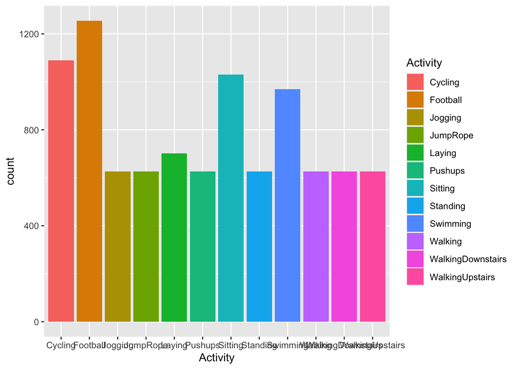

```r
recipe(Activity ~ ., df) %>%
  step_upsample(Activity, over_ratio = .5) %>%
  prep() %>%
  bake(new_data = NULL) %>%
  ggplot(aes(x = Activity, fill = Activity))+geom_bar() +
  geom_bar()
```

Next, we’ll explore the data a bit to see what it looks like while doing different activities. Notice that there are a LOT of variables in the dataset. First, we’ll just grab any two variables and make a scatterplot, with points colored by `Activity`. I chose the mean of the accelerometer data in the X- and Y-axes, called `ACCELEROMETER_X_mean` and `ACCELEROMETER_Y_mean`

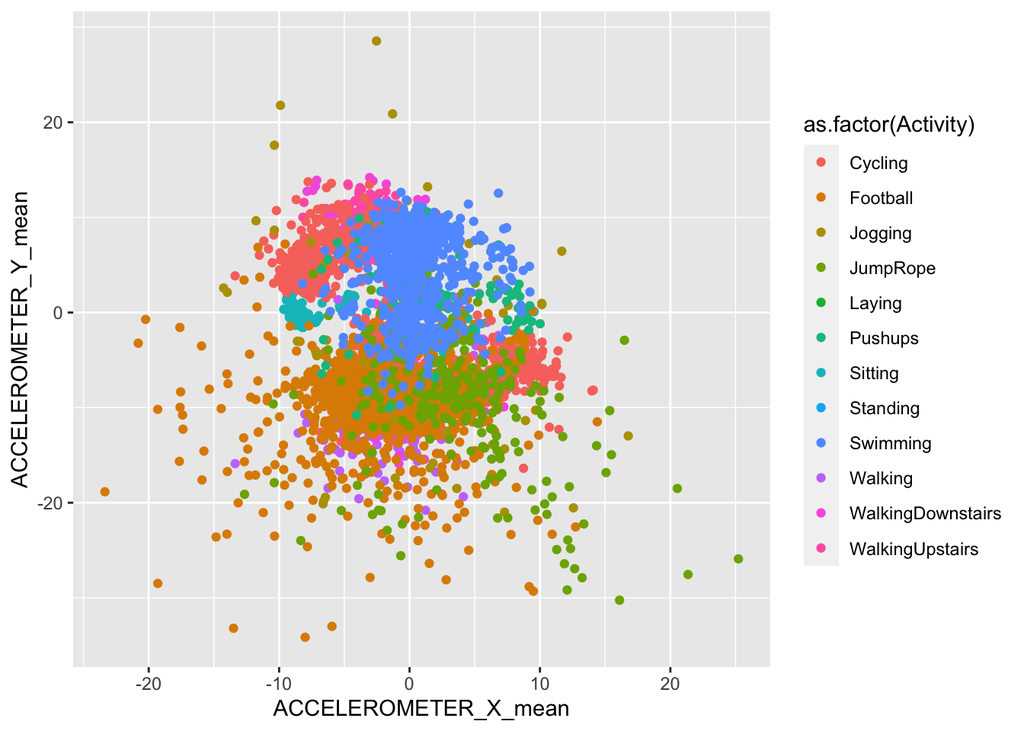

```r
ggplot(df, aes(x = ACCELEROMETER_X_mean, y = ACCELEROMETER_Y_mean, color = as.factor(Activity))) + geom_point()
```

We can see that the data is somewhat clustered. For example, there is a cloud of points associated with swimming, another for cycling and for football. But overall, it’s pretty messy, and it would probably be hard to accurately predict the activity from this data.

**Exercise 2**

Next, make the same plot as above using the X- and Y-axis means of the gravity sensor, and another for the gyroscope data. Do you notice any differences? Which pair of variables do you think would be best for predicting `Activity`?

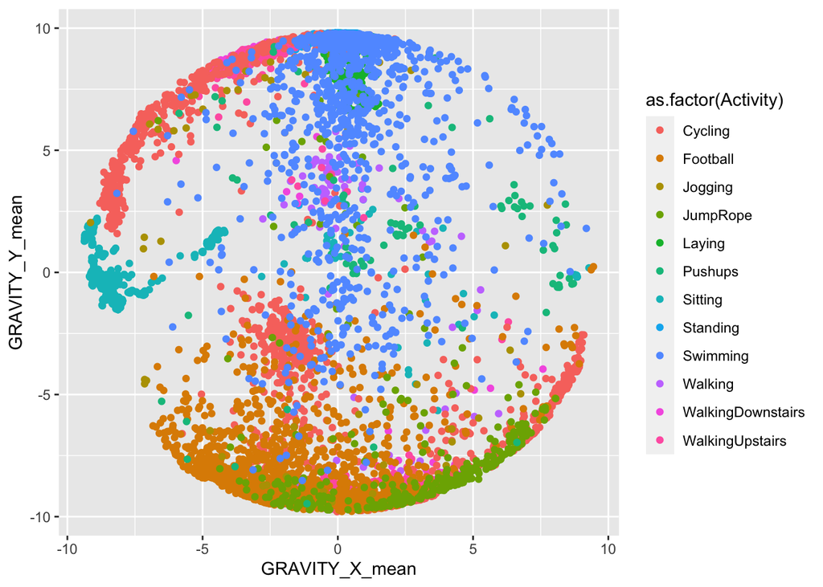

```r
ggplot(df, aes(x = GRAVITY_X_mean, y = GRAVITY_Y_mean, color = as.factor(Activity))) + geom_point()
```

The model we’ll use today, the k-nearest neighbors (KNN) algorithm, is based on the distance between points. For any two points, we can measure their distance from each other in each of the 112 dimensions. KNN assumes that “birds of a feather flock together”–meaning that observations from different `Activity` categories will cluster in distinct *regions* of this 112-dimensional space. When we encounter a new, unlabeled point and want to predict it’s class, KNN simply checks the class labels for the *k* nearest other points (in the training set) and takes their labels as “votes” to determine the label of the new point.

**Tip**

*k* (called `neighbors` in our model spec) should always be an odd number, to avoid ties in voting.